# 텍스트마이닝_2021104330 김서현

## **텍스트마이닝을 활용한 감성분석 연구동향 분석**

**비즈니스인포매틱스학과 2021104330 김서현**

### 1. 서론 : 연구배경

- 텍스트마이닝은 텍스트형태의 데이터에서 의미있는 정보를 추출하는 기술이다.
- 텍스트마이닝은 다양한 분야에서 분석도구로 사용되었으나, 텍스트마이닝 자체를 연구한 경우는 부족하다.
- 텍스트 마이닝 중 감성분석은 그 자체에 대한 범위가 넓어서 개인 연구자들이 모든 연구를 탐색하고, 파악하는데 어려움을 겪을 수 있다. 그렇기 때문에 연구자들의 연구 흐름 파악을 돕기 위해 감성분석에 대한 연구동향 분석이 필요하다.
- 기존의 감성분석 연구동향 연구들은 대체로 사용한 연구 방법론에 집중하는 경우가 많아 방법론과 주제와의 관계가 잘 드러나지 않기도 한다. 따라서 본 연구에서는 특정한 영역에 치우치지 않고 감성분석 연구동향을 종합적으로 살펴보고자 한다.

### 2. 문헌연구

선행연구는 텍스트마이닝을 통한 연구동향분석에 대한 연구와 감성분석 연구동향 선행연구로 나눠서 살펴본다.  
Kim, Y. M., & Delen, D. (2018)는 의료정보학 분야에서 주요 분야를 찾고, 시간에 따른 변화를 분석한다. TDM(Term-by-Document Matrix)를 사용하여 용어와 문서간의 관계를 확인하고, 클러스터링을 진행한 후 각 클러스터들을 해석했다.  
Minaee, S., Kalchbrenner, N., Cambria, E., Nikzad, N., Chenaghlu, M., & Gao, J. (2021)는 딥러닝 기반 텍스트분류 연구동향을 분석한다. LSTM부터 강화학습까지 150개 이상의 딥러닝 모델과 그에 대한 기술적 기여, 유사성, 장점 등을 분석하고, 각 텍스트분류 분야에서 많이 쓰이는 데이터셋과 딥러닝 모델 성능까지 살펴본다.  
김동진, 이하림, 이길재(2022)는 텍스트임베딩과 클러스터링을 활용하여 국내 경제교육의 연구동향을 분석한다. 문장의 의미를 충분하게 표현하지 못하는 BERT의 한계점을 극복하고자 문장임베딩에 특화되어 있는 SentenceBERT를 활용한다.  
이정훈(2018)은 적용분야, 방법론 등 감성분석의 다양한 영역에 대해서 탐색한다. 하지만, 영화평, 상품 후기, SNS와 같은 한정된 분야에 한해 살펴보고 방법론에 있어서도 SVM, Naïve-Bayes 등 머신러닝에 한정되어 살펴보았다는 한계가 존재한다.  
Birjali, M., Kasri, M., & Beni-Hssane, A. (2021)은 적용분야, 데이터, 방법론 등 다양하고 자세하게 어떤 연구들이 이루어지는지 분석했다. 데이터 경우 데이터 원천부터 투입 데이터의 형태, 피쳐 추출에 이르기까지 상세하게 다룬다.  
Mäntylä, M. V., Graziotin, D., & Kuutila, M. (2018)은 텍스트마이닝을 활용하여 감성분석 연구동향을 살펴본다. 해당 연구분야의 규모, 연도별 트렌드를 탐색하기 위해 감성분석에 관련된 연도별로 출판된 논문의 수, 인용수를 분석하고, 주로 출판된 저널과 각 저널에서 출판된 감성분석 논문 비율을 살펴본다. LDA(Latent Dirichlet Allocation)를 이용하여 관련된 연구주제를 추출하고, Classification tree를 통해 데이터, 분석, 목적 등으로 논문들을 분류한다.

### 3. 연구모형

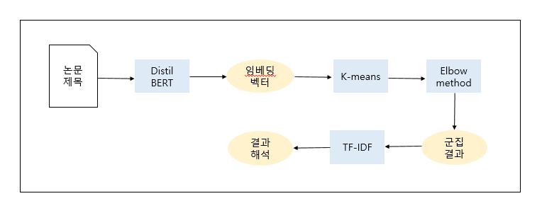

연구모형은 수집한 데이터를 DistilBERT로 임베딩된 벡터로 변환하고, Elbow method로 최적의 군집을 찾은 후, 해당 임베딩 벡터들을 최적의 군집개수대로 K-means로 클러스터링한다.

### 4. 데이터

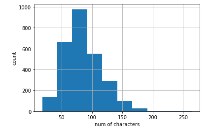

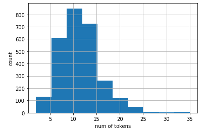

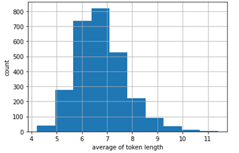

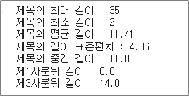

### 5. 분석결과

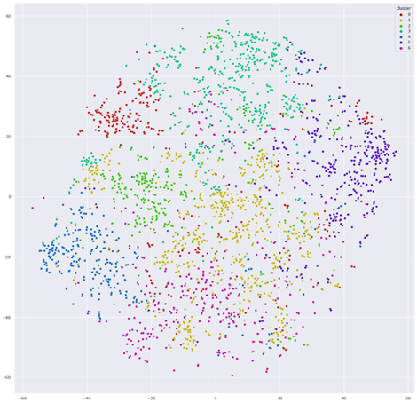

### 6. 결론

본 연구는 Google scholar와 Scopus에서 논문제목을 수집하여 활용하였다. 해당 데이터를 DistilBERT, K-means 클러스터링과 TF-IDF를 이용하여 감성분석 연구분야에 대해서 다른 연구자들에게 정보를 제공하고자 했다. 분석결과, 감성분석 관련 연구들은 7개의 클러스터로 분류되었으며, 해당 클러스터들은 감성분석 연구의 주요한 연구동향을 보여준다. 이러한 분석 결과를 바탕으로 내린 결론과 시사점은 다음과 같다.

#### 6.2. 한계점

- 본 연구에서는 Google scholar와 Scopus에 한해서 데이터를 수집하고 분석했지만, 이외에도 큰 학술데이터베이스인 Web of science와 국내 논문 학술데이터베이스 RISS 등이 포함되지 않아 수집의 범위가 제한되었다. 따라서 이러한 범위까지 수집을 넓혀 이후 연구자들에게 정보를 제공해야 한다.
- 연구결과에서 클러스터들마다 중복하여 등장하는 단어들이 존재했다. 이후 연구에서는 이러한 단어들을 분석하여 제외한 후 분석하는 방향을 시도할 필요가 있다고 본다.
- 이러한 한계점들을 바탕으로 연구동향분석들이 발전하여 분석된다면 감성분석 연구동향에 대해 후속 연구자들에게 더 자세한 연구방향을 제시할 수 있을 것이다.